# Homework 6

Puyuan Zhang

2024-11-19

## Problem 2

```r
homi_data <- read.csv("data-homicides/homicide-data.csv")
homi_data <- homi_data %>%
  mutate(city_state = paste(city, state, sep = ", "),
         victim_age = as.numeric(victim_age)
         ) |>
  filter(!(city_state %in% c("Dallas, TX", "Phoenix, AZ", "Kansas City, MO", "Tulsa, AL")),
         victim_race %in% c("White", "Black"),
         !is.na(victim_age)) |>
  mutate(solved = ifelse(disposition == "Closed by arrest", 1, 0))
```

```r
data_bal <- homi_data |>
  filter(city_state == "Baltimore, MD")
bal_model <- glm(solved ~ victim_age + victim_sex + victim_race, data = data_bal, family = "binomial")
bal_results <- tidy(bal_model, exponentiate = TRUE, conf.int = TRUE)
male_female <- bal_results %>%
  filter(term == "victim_sexMale") %>%
  select(estimate, conf.low, conf.high)
male_female
```

```
## # A tibble: 1 × 3
##   estimate conf.low conf.high
##      <dbl>    <dbl>     <dbl>
## 1    0.426    0.324     0.558
```

The adjusted odds ratio for solving homicides with male victims compared to female victims is 0.4255117. It is significantly less than 1, indicating that homicides involving male victims are less likely to be solved compared to those involving female victims.

```r
city_results <- homi_data |>
  mutate(victim_sex %in% c("Male", "Female")) |>
  group_by(city_state) |>
  nest() |>
  mutate(model = map(data, ~ glm(solved ~ victim_sex, family = "binomial", data = .)),
         tidy_model = map(model, ~ tidy(.x, exponentiate = TRUE, conf.int = TRUE))) |>
  unnest(tidy_model) |>
  filter(term == "victim_sexMale") |>
  select(city_state, estimate, conf.low, conf.high)
city_results
```

```
## # A tibble: 47 × 4
## # Groups:   city_state [47]
##    city_state      estimate conf.low conf.high
##    <chr>              <dbl>    <dbl>     <dbl>
##  1 Albuquerque, NM    1.81     0.886     3.70
##  2 Atlanta, GA        0.990    0.677     1.44
##  3 Baltimore, MD      0.387    0.297     0.503
##  4 Baton Rouge, LA    0.360    0.194     0.639
##  5 Birmingham, AL     0.887    0.584     1.34
##  6 Boston, MA         0.426    0.236     0.749
##  7 Buffalo, NY        0.449    0.253     0.791
##  8 Charlotte, NC      0.839    0.526     1.31
##  9 Chicago, IL        0.387    0.318     0.471
## 10 Cincinnati, OH     0.345    0.202     0.569
## # ℹ 37 more rows
```

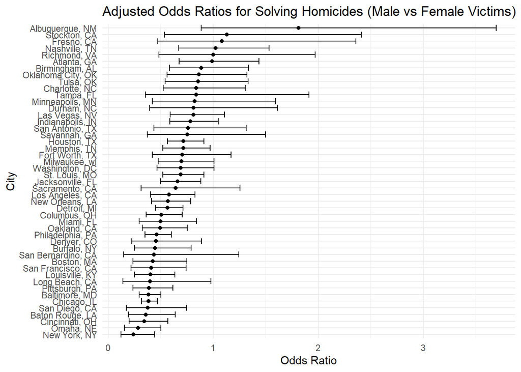

```r
ggplot(city_results, aes(x = reorder(city_state, estimate), y = estimate)) +
  geom_point() +
  geom_errorbar(aes(ymin = conf.low, ymax = conf.high)) +
  coord_flip() +
  labs(title = "Adjusted Odds Ratios for Solving Homicides (Male vs Female Victims)",
       x = "City",
       y = "Odds Ratio") +
  theme_minimal()
```

The plot shows how likely it is for homicides involving male victims to be solved compared to female victims across different cities. In most cities, cases with male victims are less likely to be solved, with odds ratios below 1. Some cities, though, show little to no difference, or even slightly higher odds for solving male victim cases. The confidence intervals for some cities are wide, likely because of small sample sizes.

## Problem 3

```r
birthweight <- read.csv("birthweight.csv")
birthweight <- birthweight %>%
  mutate(
    babysex = factor(babysex, levels = c(1, 2), labels = c("Male", "Female")),
    frace = factor(frace, levels = c(1, 2, 3, 4, 8), labels = c("White", "Black", "Asian", "Puerto Rican", "Other")),
    mrace = factor(mrace, levels = c(1, 2, 3, 4, 8), labels = c("White", "Black", "Asian", "Puerto Rican", "Other")),
    malform = factor(malform, levels = c(0, 1), labels = c("Absent", "Present"))
  ) |>
  drop_na()
summary(birthweight)
```

```
##    babysex         bhead          blength           bwt           delwt
##  Male  :2230   Min.   :21.00   Min.   :20.00   Min.   : 595   Min.   : 86.0
##  Female:2112   1st Qu.:33.00   1st Qu.:48.00   1st Qu.:2807   1st Qu.:131.0
##                Median :34.00   Median :50.00   Median :3132   Median :143.0
##                Mean   :33.65   Mean   :49.75   Mean   :3114   Mean   :145.6
##                3rd Qu.:35.00   3rd Qu.:51.00   3rd Qu.:3459   3rd Qu.:157.0
##                Max.   :41.00   Max.   :63.00   Max.   :4791   Max.   :334.0
##     fincome               frace         gaweeks         malform
##  Min.   : 0.00   White       :2123   Min.   :17.70   Absent :4327
##  1st Qu.:25.00   Black       :1911   1st Qu.:38.30   Present:  15
##  Median :35.00   Asian       :  46   Median :39.90
##  Mean   :44.11   Puerto Rican: 248   Mean   :39.43
##  3rd Qu.:65.00   Other       :  14   3rd Qu.:41.10
##  Max.   :96.00                       Max.   :51.30
##     menarche        mheight          momage              mrace
##  Min.   : 0.00   Min.   :48.00   Min.   :12.0   White       :2147
##  1st Qu.:12.00   1st Qu.:62.00   1st Qu.:18.0   Black       :1909
##  Median :12.00   Median :63.00   Median :20.0   Asian       :  43
##  Mean   :12.51   Mean   :63.49   Mean   :20.3   Puerto Rican: 243
##  3rd Qu.:13.00   3rd Qu.:65.00   3rd Qu.:22.0   Other       :   0
##  Max.   :19.00   Max.   :77.00   Max.   :44.0
##      parity            pnumlbw     pnumsga      ppbmi            ppwt
##  Min.   :0.000000   Min.   :0   Min.   :0   Min.   :13.07   Min.   : 70.0
##  1st Qu.:0.000000   1st Qu.:0   1st Qu.:0   1st Qu.:19.53   1st Qu.:110.0
##  Median :0.000000   Median :0   Median :0   Median :21.03   Median :120.0
##  Mean   :0.002303   Mean   :0   Mean   :0   Mean   :21.57   Mean   :123.5
##  3rd Qu.:0.000000   3rd Qu.:0   3rd Qu.:0   3rd Qu.:22.91   3rd Qu.:134.0
##  Max.   :6.000000   Max.   :0   Max.   :0   Max.   :46.10   Max.   :287.0
##      smoken           wtgain
##  Min.   : 0.000   Min.   :-46.00
##  1st Qu.: 0.000   1st Qu.: 15.00
##  Median : 0.000   Median : 22.00
##  Mean   : 4.145   Mean   : 22.08
##  3rd Qu.: 5.000   3rd Qu.: 28.00
##  Max.   :60.000   Max.   : 89.00
```

```r
model_1 <- lm(bwt ~ ., data = birthweight)
summary(model_1)
```

```
##
## Call:
## lm(formula = bwt ~ ., data = birthweight)
##
## Residuals:
##      Min       1Q   Median       3Q      Max
## -1097.68  -184.86    -3.33   173.09  2344.15
##
## Coefficients: (3 not defined because of singularities)
##                     Estimate Std. Error t value Pr(>|t|)
## (Intercept)       -6265.3914   660.4011  -9.487  < 2e-16 ***
## babysexFemale        28.7073     8.4652   3.391 0.000702 ***
## bhead               130.7781     3.4523  37.881  < 2e-16 ***
## blength              74.9536     2.0217  37.075  < 2e-16 ***
## delwt                 4.1007     0.3948  10.386  < 2e-16 ***
## fincome               0.2898     0.1795   1.614 0.106551
## fraceBlack           14.3313    46.1501   0.311 0.756168
## fraceAsian           21.2361    69.2960   0.306 0.759273
## fracePuerto Rican   -46.9962    44.6782  -1.052 0.292912
## fraceOther            4.2969    74.0741   0.058 0.953745
## gaweeks              11.5494     1.4654   7.882 4.06e-15 ***
## malformPresent        9.7650    70.6259   0.138 0.890039
## menarche             -3.5508     2.8951  -1.226 0.220083
## mheight               9.7874    10.3116   0.949 0.342588
## momage                0.7593     1.2221   0.621 0.534418
## mraceBlack         -151.4354    46.0453  -3.289 0.001014 **
## mraceAsian          -91.3866    71.9190  -1.271 0.203908
## mracePuerto Rican   -56.4787    45.1369  -1.251 0.210901
## parity               95.5411    40.4793   2.360 0.018307 *
## pnumlbw                   NA         NA      NA       NA
## pnumsga                   NA         NA      NA       NA
## ppbmi                 4.3538    14.8913   0.292 0.770017
## ppwt                 -3.4716     2.6121  -1.329 0.183913
## smoken               -4.8544     0.5871  -8.269  < 2e-16 ***
## wtgain                    NA         NA      NA       NA
## ---
## Signif. codes:  0 '***' 0.001 '**' 0.01 '*' 0.05 '.' 0.1 ' ' 1
##
## Residual standard error: 272.5 on 4320 degrees of freedom
## Multiple R-squared:  0.7183, Adjusted R-squared:  0.717
## F-statistic: 524.6 on 21 and 4320 DF,  p-value: < 2.2e-16
```

I plan to use p-value to select the factor that may be significant to the prediction, which has p-value lower than 0.05. So, I select babysex, bhead, blength, delwt, gaweeks, parity, mrace, smoken to predict the weight of babies.

```r
model_2 <- lm(bwt ~ babysex + bhead + blength + delwt + gaweeks + parity + mrace + smoken, data = birthweight)
summary(model_2)
```

```
##
## Call:
## lm(formula = bwt ~ babysex + bhead + blength + delwt + gaweeks +
##     parity + mrace + smoken, data = birthweight)
##
## Residuals:
##      Min       1Q   Median       3Q      Max
## -1119.67  -181.24    -5.87   173.51  2340.76
##
## Coefficients:
##                     Estimate Std. Error t value Pr(>|t|)
## (Intercept)       -5822.5934    98.8325 -58.914  < 2e-16 ***
## babysexFemale        28.6609     8.4951   3.374 0.000748 ***
## bhead               131.6982     3.4607  38.056  < 2e-16 ***
## blength              75.8653     2.0210  37.538  < 2e-16 ***
## delwt                 2.2649     0.1961  11.550  < 2e-16 ***
## gaweeks              12.1400     1.4654   8.284  < 2e-16 ***
## parity               98.6113    40.5334   2.433 0.015021 *
## mraceBlack         -146.7893     9.2435 -15.880  < 2e-16 ***
## mraceAsian          -71.5880    42.4809  -1.685 0.092026 .
## mracePuerto Rican  -119.5979    18.7656  -6.373 2.04e-10 ***
## smoken               -4.7472     0.5882  -8.071 8.96e-16 ***
## ---
## Signif. codes:  0 '***' 0.001 '**' 0.01 '*' 0.05 '.' 0.1 ' ' 1
##
## Residual standard error: 273.8 on 4331 degrees of freedom
## Multiple R-squared:  0.7148, Adjusted R-squared:  0.7142
## F-statistic:  1086 on 10 and 4331 DF,  p-value: < 2.2e-16
```

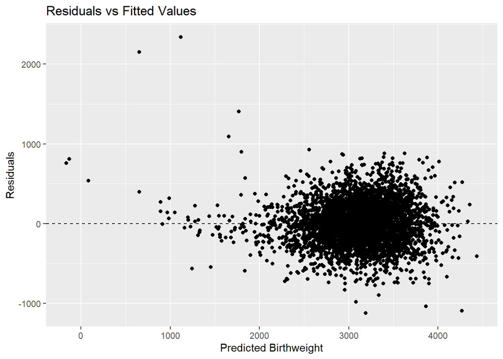

```r
birthweight <- birthweight |>
  add_predictions(model_2, var = "predicted_bwt") |>
  add_residuals(model_2, var = "residual_bwt")

ggplot(birthweight, aes(x = predicted_bwt, y = residual_bwt)) +
  geom_point() +
  geom_hline(yintercept = 0, linetype = "dashed") +
  labs(title = "Residuals vs Fitted Values", x = "Predicted Birthweight", y = "Residuals")
```

```r
model_3 <- lm(bwt ~ blength + gaweeks, data = birthweight)
model_4 <- lm(bwt ~ bhead * blength * babysex, data = birthweight)
```

```r
set.seed(1119)
cv_df<- crossv_mc(birthweight, 10) |>
  mutate(
    train = map(train, as_tibble),
    test = map(test, as_tibble)
  )

cv_df <- cv_df |>
  mutate(
    linear_mod = map(train, ~ lm(bwt ~ babysex + bhead + blength + delwt + gaweeks + parity + mrace + smoken, data = .x)),
    simple_mod = map(train, ~ lm(bwt ~ blength + gaweeks, data = .x)),
    interaction_mod = map(train, ~ lm(bwt ~ bhead * blength * babysex, data = .x))
  )

cv_df <- cv_df |>
  mutate(
    rmse_linear = map2_dbl(linear_mod, test, ~ rmse(model = .x, data = .y)),
    rmse_simple = map2_dbl(simple_mod, test, ~ rmse(model = .x, data = .y)),
    rmse_interaction = map2_dbl(interaction_mod, test, ~ rmse(model = .x, data = .y))
  )
```

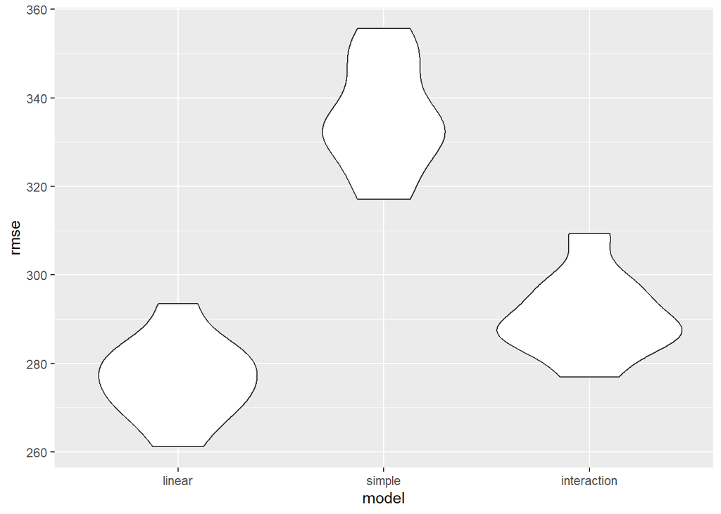

```r
cv_df |>
  select(starts_with("rmse")) |>
  pivot_longer(
    everything(),
    names_to = "model",
    values_to = "rmse",
    names_prefix = "rmse_") |>
  mutate(model = fct_inorder(model)) |>
  ggplot(aes(x = model, y = rmse)) + geom_violin()
```